# April Model Changes

Alan

4/27/2020

## v9004 to February Official

Changes include:

- Moved rule ‘Set ICS Put and Take Dates’ to the lowest priority rule in both the IGDCP and NA ruleset. Rule is now part of a new policy group ‘Set Operational Dates’.
- updated Havasu power method to match MTOM

All KeySlots are equal (only the run date and ruleset names change)

```r
compare_rdfs(rdfs = "KeySlots.rdf", base_scen = feb_dnf, new_scens = v9004_dnf)
```

```
## Scenario: ~/crss/crss.offc/Scenario//Feb2020_2021_9004,DNF,2007Dems,IG_DCP_9001,MTOM_Most to M:/Shared/CRSS/2020/Scenario/Feb2020_2021,DNF,2007Dems,IG_DCP,MTOM_Most
```

```
## ------ KeySlots.rdf --------
```

```
##   [1] "Component \"meta\": Component \"create_date\": 1 string mismatch"
##   [2] "Component \"runs\": Component 1: Component 8: 1 string mismatch"
##   [3] "Component \"runs\": Component 2: Component 8: 1 string mismatch"
##   [4] "Component \"runs\": Component 3: Component 8: 1 string mismatch"
##   [5] "Component \"runs\": Component 4: Component 8: 1 string mismatch"
##   [6] "Component \"runs\": Component 5: Component 8: 1 string mismatch"
##   [7] "Component \"runs\": Component 6: Component 8: 1 string mismatch"
##   [8] "Component \"runs\": Component 7: Component 8: 1 string mismatch"
##   [9] "Component \"runs\": Component 8: Component 8: 1 string mismatch"
##  [10] "Component \"runs\": Component 9: Component 8: 1 string mismatch"
##  [11] "Component \"runs\": Component 10: Component 8: 1 string mismatch"
##  [12] "Component \"runs\": Component 11: Component 8: 1 string mismatch"
##  [13] "Component \"runs\": Component 12: Component 8: 1 string mismatch"
##  [14] "Component \"runs\": Component 13: Component 8: 1 string mismatch"
##  [15] "Component \"runs\": Component 14: Component 8: 1 string mismatch"
```

[output cut: 99 more lines]

## v9005 to v9004/February Official

Changes include:

- updated `UBRuleCurveData.ReservoirData["Navajo", "liveCapacityStorage"]`

This change affects the computation of `PowellForecastData.Reg Inflow with Error[]`, which in turn affects the computation of all EOWY forecasts through changing the total UB `UBEffectiveStorage()` computation and thus the forecast inflow to Powell, which is used in EOWY forecasts and UBDO related forecasts.

Interestingly, it does not affect Navajo’s release:

```r
ubres_feb <- read_rdf(file.path(feb_dnf, "UBRes.rdf"))
ubres_9005 <- read_rdf(file.path(v9005_dnf, "UBRes.rdf"))
all.equal(rdf_get_slot(ubres_feb, "Navajo.Outflow"), rdf_get_slot(ubres_9005, "Navajo.Outflow"))
```

```
## [1] TRUE
```

But it does affect Flaming Gorge’s release (through a connection with the UBDO which is based on a forecast future elevation at Powell.)

```r
all.equal(rdf_get_slot(ubres_feb, "FlamingGorge.Outflow"), rdf_get_slot(ubres_9005, "FlamingGorge.Outflow"))
```

```
## [1] "Mean relative difference: 0.02980451"
```

```r
key_feb <- read_rdf(file.path(feb_dnf, "KeySlots.rdf"))
key_9005 <- read_rdf(file.path(v9005_dnf, "KeySlots.rdf"))
p_diff <- abs(rdf_get_slot(key_feb, "Powell.Pool Elevation") -
                rdf_get_slot(key_9005, "Powell.Pool Elevation"))
m_diff <- abs(rdf_get_slot(key_feb, "Mead.Pool Elevation") -
                rdf_get_slot(key_9005, "Mead.Pool Elevation"))
p_prct <- formatC(
  length(which(p_diff != 0)) / length(p_diff) * 100,
  digits = 2, format = "f"
)
m_prct <- formatC(
  length(which(m_diff != 0)) / length(m_diff) * 100,
  digits = 2, format = "f"
)

p_mag <- formatC(mean(p_diff), digits = 2, format = "f")
m_mag <- formatC(mean(m_diff), digits = 2, format = "f")
```

Of course this can have downstream affects on Powell and Mead’s elevations. Overall, 52.90 and 55.00 % of months are affected at Powell and Mead, respectively. There is an average absolute difference of 0.14 and 0.16 feet, respectively.

## v9006 to v9005

The final change includes an update to `UBRuleCurveData.ReservoirData["Mead", "liveCapacityStorage"]`.

The results are compared to the previous run (with udpates to Navajo), so we can isolate the differences in this change by itself.

```r
key_9006 <- read_rdf(file.path(v9006_dnf, "KeySlots.rdf"))
ubres_9006 <- read_rdf(file.path(v9006_dnf, "UBRes.rdf"))
```

```r
p_diff <- abs(rdf_get_slot(key_9005, "Powell.Pool Elevation") -
                rdf_get_slot(key_9006, "Powell.Pool Elevation"))
m_diff <- abs(rdf_get_slot(key_9005, "Mead.Pool Elevation") -
                rdf_get_slot(key_9006, "Mead.Pool Elevation"))
p_prct <- formatC(
  length(which(p_diff != 0)) / length(p_diff) * 100,
  digits = 2, format = "f"
)
m_prct <- formatC(
  length(which(m_diff != 0)) / length(m_diff) * 100,
  digits = 2, format = "f"
)

p_mag <- formatC(mean(p_diff), digits = 2, format = "f")
m_mag <- formatC(mean(m_diff), digits = 2, format = "f")
```

Upating the Mead live capacity value affects computations in the Mead Flood Control rule. Overall, this affect 30.10 % of months at Mead, with an average absolute difference of 0.46 ft. When Mead’s elevations change, this can have upstream affects on Powell. 11.96 % of months are affected at Powell with an average absolute difference of 0.14.

And if Powell’s elevations change, the UBDO can have affects on other UB reservoirs, e.g., at Flaming Gorge (outflow):

```r
all.equal(rdf_get_slot(ubres_9005, "FlamingGorge.Outflow"),
          rdf_get_slot(ubres_9006, "FlamingGorge.Outflow"))
```

```
## [1] "Mean relative difference: 0.1641871"
```

```r
fg_diff <- abs(rdf_get_slot(ubres_9005, "FlamingGorge.Outflow")-
          rdf_get_slot(ubres_9006, "FlamingGorge.Outflow"))
fg_prct <- formatC(
  length(which(fg_diff != 0)) / length(p_diff) * 100,
  digits = 2, format = "f"
)
fg_mag <- formatC(mean(fg_diff), digits = 2, format = "f")
```

0.18 % of months are different at Flaming Gorge, with an average absolute difference of 49.09 acre-ft.

## Final Comparison of all Changes

All told, the results have minimal affects on Powell and Mead’s elevations as shown in the following figures. Comparisons are included for DNF and Stress Test; One comparison is made for the “Revert to 2007 No-Action Alternative” ruleset; the current trends demand scenario is included for this run as there was a minor change in that DIT.

```r
get_and_filter <- function(scen, scen_name) {
  rdf_to_rwtbl2(file.path(scen, "KeySlots.rdf")) %>%
    filter(ObjectSlot %in% c("Mead.Pool Elevation", "Powell.Pool Elevation"),
           Month == "December") %>%
    group_by(Year, ObjectSlot) %>%
    summarise(
      q10 = quantile(Value, 0.1),
      q50 = median(Value),
      q90 = quantile(Value, 0.9)
    ) %>%
    pivot_longer(cols = starts_with("q"), names_to = "percentile") %>%
    mutate(scen = scen_name)
}

zz <- bind_rows(
  get_and_filter(feb_dnf, "feb_dnf"),
  get_and_filter(feb_na, "feb_na"),
  get_and_filter(feb_st, "feb_st"),
  get_and_filter(v9006_dnf, "v9006_dnf"),
  get_and_filter(v9006_st, "v9006_st"),
  get_and_filter(v9006_na, "v9006_na"),
  get_and_filter(v9006_ct, "v9006_ct")
)
```

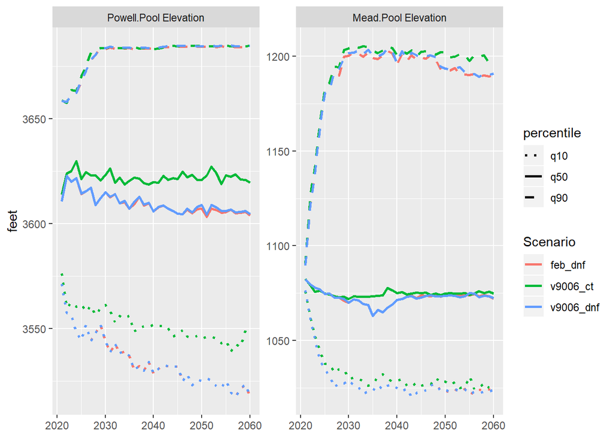

```r
plot_scens <- function(zz, scens) {
  ltype <- c("q10" = 3, "q50" = 1, "q90" = 2)
  zz$ObjectSlot <- factor(zz$ObjectSlot,
                          levels = c("Powell.Pool Elevation", "Mead.Pool Elevation"))
  filter(zz, scen %in% scens) %>%
    ggplot(aes(Year, value, color = scen, linetype = percentile)) +
    geom_line(size = 1) +
    facet_wrap(~ObjectSlot, ncol = 2, scales = "free_y") +
    scale_linetype_manual(values = ltype) +
    labs(color = "Scenario", x = NULL, y = "feet")
}

plot_scens(zz, c("feb_dnf", "v9006_dnf", "v9006_ct"))
```

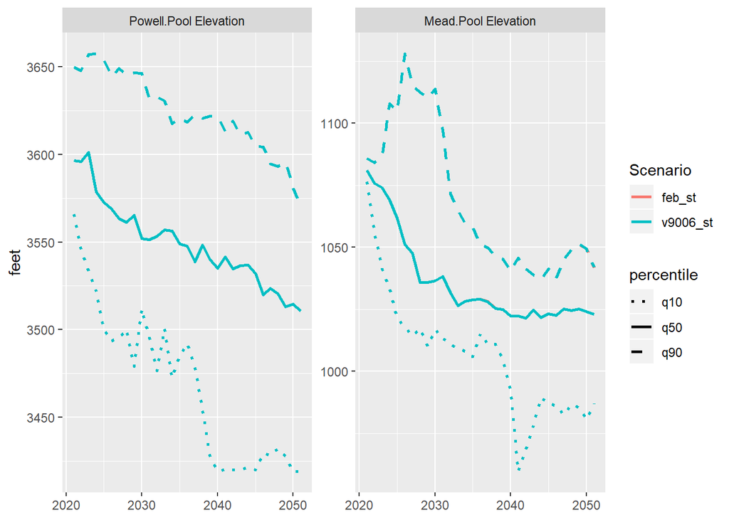

```r
plot_scens(zz, c("feb_st", "v9006_st"))
```

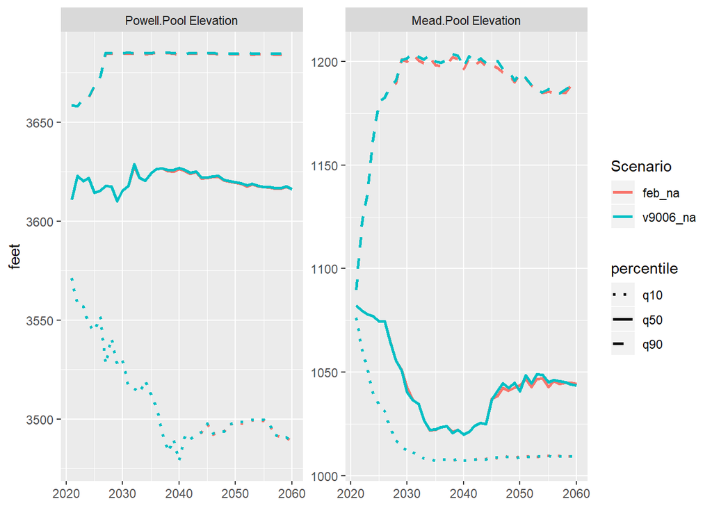

```r
plot_scens(zz, c("feb_na", "v9006_na"))
```